# Eye Fitting Straight Lines (in the Modern Era)

Emily

Spring 2021

### Summary of [Eye Fitting Straight Lines](http://www.tandfonline.com/doi/abs/10.1080/00031305.1981.10479335)

- Mosteller, F., Siegel, A. F., Trapido, E., & Youtz, C. (1981). Eye fitting straight lines. The American Statistician, 35(3), 150-152.

### Method/Procedure

- Method involves maneuvering a string, black thread, or ruler until the fit seems satisfactory, and then drawing the line.
- Students fitted lines by eye to four sets of points (S, F, V, N).
- Sample: graduate students and post doc students in introductory biostatistics (most had not studied statistics before).
  - laid out 175 packets, collected 153 at the end of the hour.
  - Each student was given the same set of four scatter diagrams and an 8.5 x 11 inch transparency with a straight line etched completely across the middle.

### Parameters

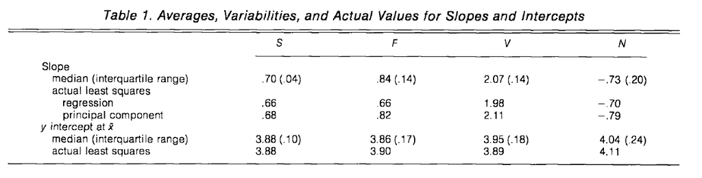

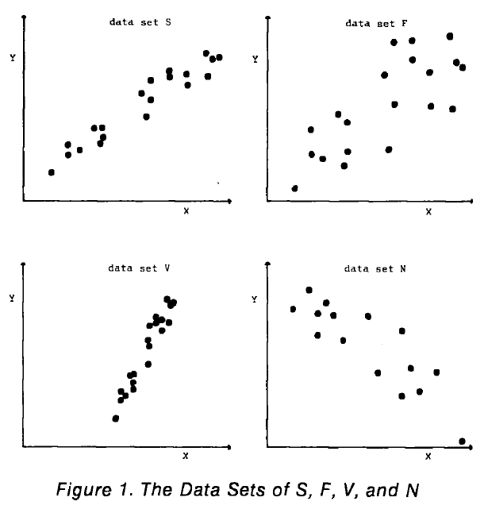

## Experimental Design

Latin square with packets stapeled in four different orders:

- SNFV
- NSVF
- FVSN
- VFNS

Distributed systematically in sequence so that students sitting side by side had different kinds of packets.

### Results

- Students tended to fit the slope of the first principal component or major axis (the line that minimizes the sum of squares of perpendicular rather than vertical distances).
- Students had a slight tendency to choose consistently either steeper or shallower slopes for all sets of data.
- Individual-to-individual variability in slope and in intercept was near the standard error provided by least squares for the four data sets *(no theory ecourages us to beleive in such relations)*.
- Found no trend in the differences due to order.

### Considerations for Eye Fitting Straight Lines in the Modern Era

- You Draw It does not restrict participants to a straight line.
- Does order matter?

```r
ydi_parms <- data.frame(
           dataset = c("S", "F", "V", "N"),
           y_xbar = c(3.88, 3.9, 3.89, 4.11),
           slope  = c(0.66, 0.66, 1.98, -0.70),
           sigma  = c(1.3, 2.8, 1.5, 2.5),
           xmin   = c(0, 0, 5, 0),
           xmax   = c(20, 20, 15, 20)
           )
ydi_parms %>%
  kable(cap = "Simulation Parameters for 'You Draw it'")
```

Simulation Parameters for ‘You Draw it’

| dataset | y_xbar | slope | sigma | xmin | xmax |
| --- | --- | --- | --- | --- | --- |
| S | 3.88 | 0.66 | 1.3 | 0 | 20 |
| F | 3.90 | 0.66 | 2.8 | 0 | 20 |
| V | 3.89 | 1.98 | 1.5 | 5 | 15 |
| N | 4.11 | -0.70 | 2.5 | 0 | 20 |

```r
linearYDI_simFunc <-
  function(y_xbar, slope, sigma, xmin = 0, xmax = 20, by = 0.25, N = 30, points_end_scale = 1){

  xLine <- seq(xmin, xmax, by = by)
  xPoint <- sample(xLine[xLine <= xmax*points_end_scale], size = N, replace = F)
  # From slope intercept form
  # y-y_xbar = m(x-xbar)
  # y = m(x-xbar) + y_xbar = mx - mxbar + y_xbar
  yintercept = y_xbar - slope*mean(xPoint)

  line_data <- tibble(x = xLine,
                      y = yintercept + slope*x)

  # generate point data
  repeat{
    errorVals <- rnorm(N, 0, sigma)
    if(mean(errorVals[10]) < 2*sigma & mean(errorVals[10] > -2*sigma)){
      break
    }
  }
  point_data <- tibble(x = xPoint,
                       ypoints = yintercept + slope*x + errorVals)

  data <- full_join(line_data, point_data, by = "x")%>%
      mutate(ypoints = ifelse(is.na(ypoints), -999, ypoints))

  # return(list(line_data = line_data, point_data = point_data, data = data))
  return(data)

}
```

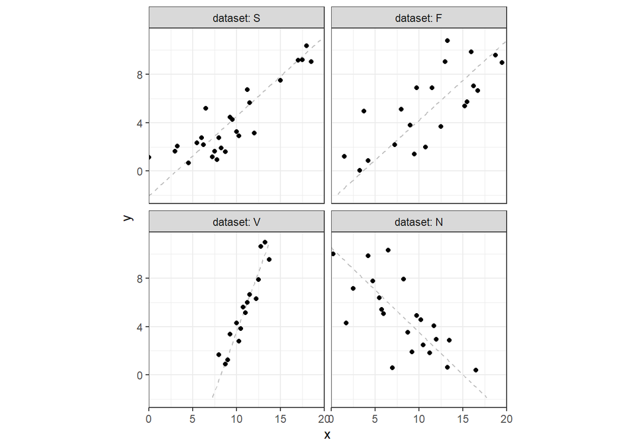

```r
ydi_data <- ydi_parms %>%
  mutate(data = purrr::pmap(list(y_xbar, slope, sigma, xmin, xmax), linearYDI_simFunc)) %>%
  unnest(data)

ydi_data %>%
  mutate(dataset = factor(dataset, levels = c("S", "F", "V", "N"))) %>%
  ggplot(aes(x = x, y = y)) +
  geom_line(color = "gray", linetype = 2) +
  geom_point(data = ydi_data %>% filter(ypoints > 0), aes(x = x, y = ypoints)) +
  theme_bw() +
  theme(aspect.ratio = 1) +
  facet_wrap(~dataset, ncol = 2,
             labeller = labeller(dataset = label_both)) +
  scale_x_continuous(expand = c(0,0)) +
  scale_y_continuous(limits = c(min(ydi_data$y[ydi_data$dataset == "S"]), max(ydi_data$y[ydi_data$dataset == "S"])))
```